# Business Statistic Project 2

### Observation

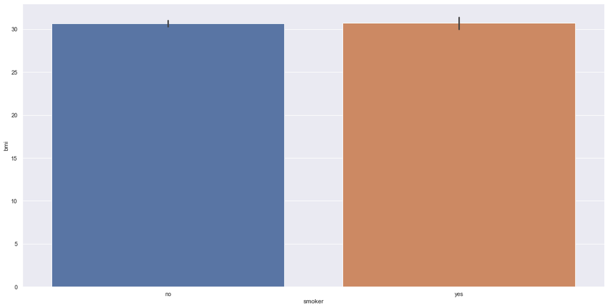

```python
plt.figure(figsize = (20,10))
sns.barplot(x="smoker", y="bmi",data=data)
```

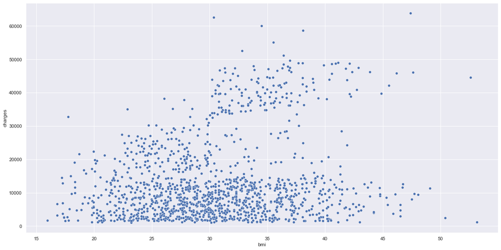

```python
plt.figure(figsize = (20,10))
sns.scatterplot(x="bmi", y="charges",data=data)
```

### Observation

1. Customers charges ar more concentrated between BMI 20-35 and charges of 1000-12,000.
2. Customers with higher charges are fewer but in a range of BMI 30-40.

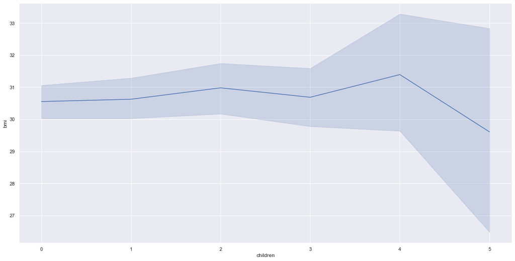

```python
plt.figure(figsize = (20,10))
sns.lineplot(x="children", y="bmi",data=data)
```

### Observation

1. customers with 0-4 children are in a BMI ranger of 30-31.
2. Customers with 5 children have BMI of 29.

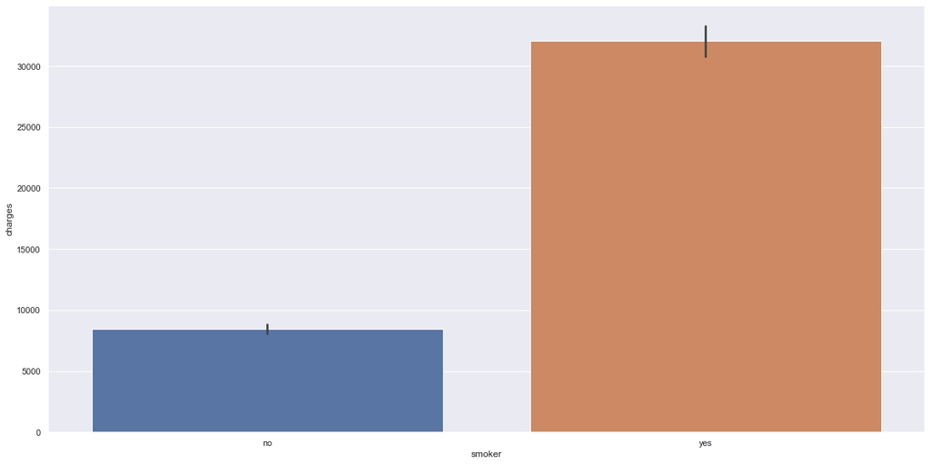

```python
plt.figure(figsize = (20,10))
sns.barplot(x="smoker", y="charges",data=data)
```

### Observation

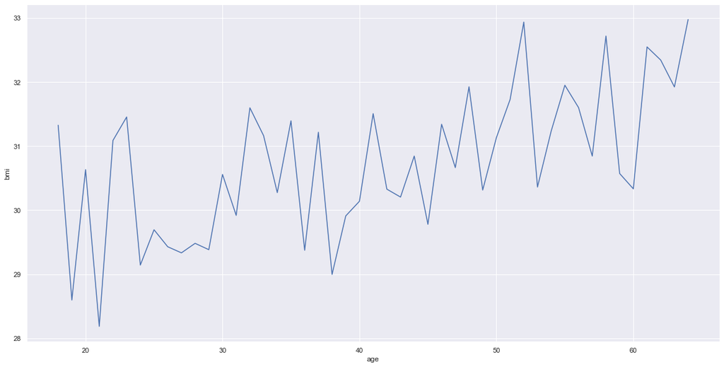

```python
plt.figure(figsize = (20,10)) # To resize the plot
sns.lineplot(x='age', y='bmi', data=data, ci=None, )
```

##### Observation

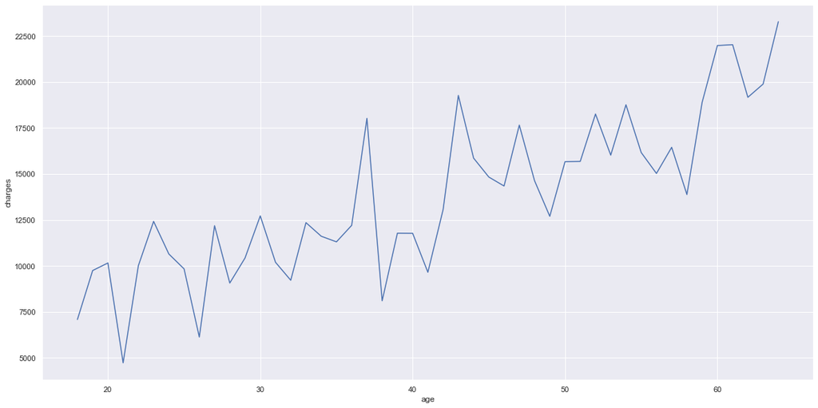

```python
plt.figure(figsize = (20,10)) # To resize the plot
sns.lineplot(x='age', y='charges', data=data, ci=None, )
```

### Observation

1. The charges is ascending with Age.
2. The older the customer, higher the medical claims

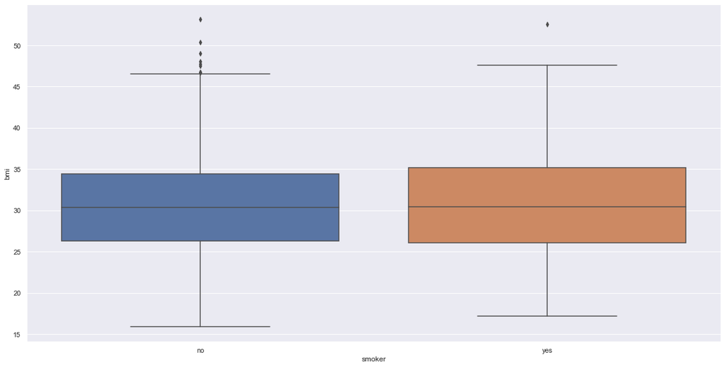

```python
plt.figure(figsize = (20,10))
sns.boxplot(x="smoker", y="bmi",data=data)
```

#### Observation

1. Smoker and BMI are most evenly distributed.
2. The mean are the same.

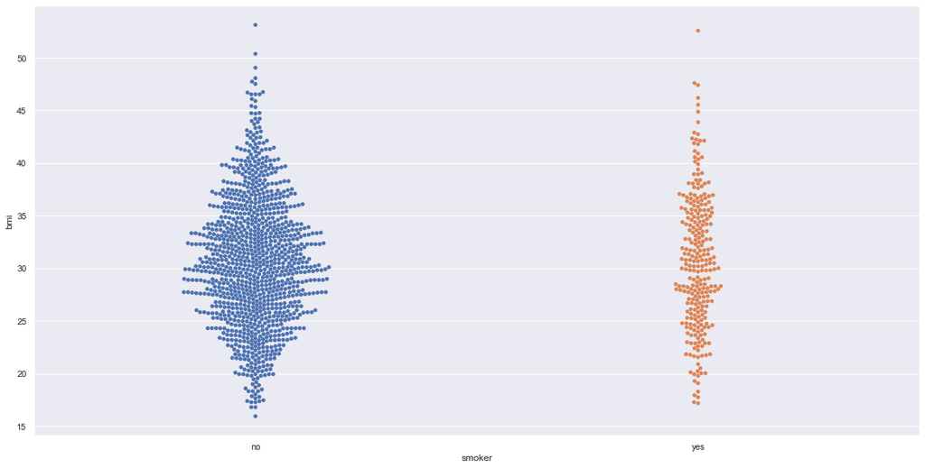

```python
plt.figure(figsize = (20,10)) # To resize the plot
sns.swarmplot(x='smoker', y='bmi', data=data)
```

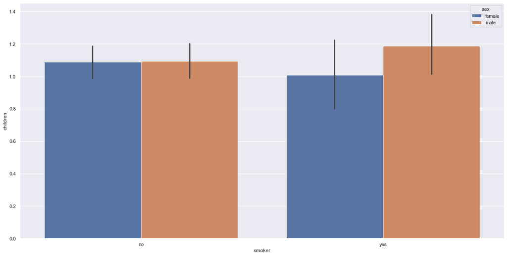

```python
plt.figure(figsize = (20,10))
sns.barplot(x="smoker", y="children",data=data, hue="sex")
```